# Distancia recorrida Incilius spiculatus

# Preparar los datos

## Importar dataframe

Importaremos los datos del archivo excel que nos envio el **midgardo** asegurandonos de que ya estamos en el directorio de trabajo adecuado

```r
> #importar datos
> df1 <- readxl::read_excel(here("Data", "spicu2.xlsx"), sheet = "in")
```

Veamos como estan los datos para poder organizarlos

```r
> df1
```

```
## # A tibble: 30 x 26
##    Especie Sitio Individuo Sexo  Edad  Distancia24hrs `Distancia tota~ Mes
##    <chr>   <chr>     <dbl> <chr> <chr> <chr>                     <dbl> <chr>
##  1 Incili~ Cons~         1 Juve~ Juve~ .                          85.9 Marzo
##  2 Incili~ Pert~         2 Juve~ Juve~ .                          36.3 Octu~
##  3 Incili~ Pert~         3 Juve~ Juve~ .                          27.2 Novi~
##  4 Incili~ Pert~         4 Macho Adul~ 18.46                      18.5 Dici~
##  5 Incili~ Cons~         5 Macho Adul~ 39.27333333               121.  Agos~
##  6 Incili~ Cons~         6 Macho Adul~ 26.4                      143.  Agos~
##  7 Incili~ Cons~         7 Hemb~ Adul~ 32.445                    140.  Agos~
##  8 Incili~ Cons~         8 Macho Adul~ 33.0200000000~             66.0 Agos~
##  9 Incili~ Pert~         9 Macho Adul~ 25.67                      87.6 Agos~
## 10 Incili~ Pert~        10 Hemb~ Adul~ 51.0349999999~            246.  Agos~
## # ... with 20 more rows, and 18 more variables: Temporada <chr>, LHC <dbl>,
## #   Peso <dbl>, `RESIDUOS POR SEXO` <dbl>, Observaciones_Inmovil <dbl>,
## #   Moviendose <dbl>, `Total de observaciones` <dbl>, `% Inmovil` <dbl>, `%
## #   Moviendose` <dbl>, MCP_Area_m <dbl>, MCP_Perimetro <dbl>, NDVI_SMO <dbl>,
## #   EVI_SMO <dbl>, NDWI_SMO <dbl>, NDMI_SMO <dbl>, LST_SMO <dbl>,
## #   CME_SMO_15 <dbl>, `Altura de arbol` <dbl>
```

Con la funcion `str()` podemos ver la estructura de un dataframe y la informacion relevante de este

```r
> str(df1)
```

```
## tibble [30 x 26] (S3: tbl_df/tbl/data.frame)
##  $ Especie                  : chr [1:30] "Incilius spiculatus" "Incilius spiculatus" "Incilius spiculatus" "Incilius spiculatus" ...
##  $ Sitio                    : chr [1:30] "Conservado" "Perturbado" "Perturbado" "Perturbado" ...
##  $ Individuo                : num [1:30] 1 2 3 4 5 6 7 8 9 10 ...
##  $ Sexo                     : chr [1:30] "Juvenil" "Juvenil" "Juvenil" "Macho" ...
##  $ Edad                     : chr [1:30] "Juvenil" "Juvenil" "Juvenil" "Adulto" ...
##  $ Distancia24hrs           : chr [1:30] "." "." "." "18.46" ...
##  $ Distancia total reccorida: num [1:30] 85.9 36.3 27.2 18.5 121.4 ...
##  $ Mes                      : chr [1:30] "Marzo" "Octubre" "Noviembre" "Diciembre" ...
##  $ Temporada                : chr [1:30] "Secas" "Secas" "Secas" "Secas" ...
##  $ LHC                      : num [1:30] 5.92 5.47 6 7.23 7.71 ...
##  $ Peso                     : num [1:30] 19.4 14.9 29.5 31 50.5 ...
##  $ RESIDUOS POR SEXO        : num [1:30] -4.528 0.684 3.845 -7.954 2.235 ...
##  $ Observaciones_Inmovil    : num [1:30] 1 1 0 0 2 14 2 6 2 1 ...
##  $ Moviendose               : num [1:30] 10 2 3 3 14 14 15 7 11 21 ...
##  $ Total de observaciones   : num [1:30] 11 3 3 3 16 28 17 13 13 22 ...
##  $ % Inmovil                : num [1:30] 9.09 33.33 0 0 12.5 ...
##  $ % Moviendose             : num [1:30] 90.9 66.7 100 100 87.5 ...
##  $ MCP_Area_m               : num [1:30] 340.8 162.9 80.9 15.2 234 ...
##  $ MCP_Perimetro            : num [1:30] 74.8 64.5 45.8 23.4 64.2 ...
##  $ NDVI_SMO                 : num [1:30] 0.851 0.831 0.834 0.829 0.568 ...
##  $ EVI_SMO                  : num [1:30] 0.642 0.583 0.58 0.586 0.487 ...
##  $ NDWI_SMO                 : num [1:30] -0.79 -0.788 -0.773 -0.763 -0.561 ...
##  $ NDMI_SMO                 : num [1:30] 0.4 0.354 0.4 0.383 0.268 ...
##  $ LST_SMO                  : num [1:30] 19.2 18.8 18.5 18.8 18 ...
##  $ CME_SMO_15               : num [1:30] 1531 1501 1311 1305 1532 ...
##  $ Altura de arbol          : num [1:30] 14.93 19.44 4.23 8.31 7.44 ...
```

Veamos la base de datos completa

|  | Especie | Sitio | Individuo | Sexo | Edad | Distancia24hrs | Distancia total reccorida | Mes | Temporada | LHC | Peso | RESIDUOS POR SEXO | Observaciones_Inmovil | Moviendose | Total de observaciones | % Inmovil | % Moviendose | MCP_Area_m | MCP_Perimetro | NDVI_SMO | EVI_SMO | NDWI_SMO | NDMI_SMO | LST_SMO | CME_SMO_15 | Altura de arbol |
| --- | --- | --- | --- | --- | --- | --- | --- | --- | --- | --- | --- | --- | --- | --- | --- | --- | --- | --- | --- | --- | --- | --- | --- | --- | --- | --- |
| 1 | Incilius spiculatus | Conservado | 1 | Juvenil | Juvenil | . | 85.92 | Marzo | Secas | 5.92 | 19.4 | -4.528481013 | 1 | 10 | 11 | 9.090909091 | 90.90909091 | 340.805659 | 74.79403055 | 0.85133 | 0.6416 | -0.78994 | 0.39995 | 19.18094 | 1531 | 14.92712402 |
| 2 | Incilius spiculatus | Perturbado | 2 | Juvenil | Juvenil | . | 36.33 | Octubre | Secas | 5.47 | 14.9 | 0.683544304 | 1 | 2 | 3 | 33.33333333 | 66.66666667 | 162.9166531 | 64.49833698 | 0.83107 | 0.58272 | -0.7882 | 0.35398 | 18.75687 | 1501 | 19.44335938 |
| 3 | Incilius spiculatus | Perturbado | 3 | Juvenil | Juvenil | . | 27.18 | Noviembre | Secas | 6 | 29.5 | 3.844936709 | 0 | 3 | 3 | 0 | 100 | 80.93322478 | 45.76472091 | 0.83365 | 0.58027 | -0.7733 | 0.40003 | 18.45731 | 1311 | 4.2265625 |
| 4 | Incilius spiculatus | Perturbado | 4 | Macho | Adulto | 18.46 | 18.46 | Diciembre | Secas | 7.23 | 31 | -7.953691578 | 0 | 3 | 3 | 0 | 100 | 15.24829629 | 23.44003805 | 0.82863 | 0.586 | -0.76292 | 0.3828 | 18.78955 | 1305 | 8.311645508 |
| 5 | Incilius spiculatus | Conservado | 5 | Macho | Adulto | 39.27333333 | 121.44 | Agosto | lluvias | 7.71 | 50.5 | 2.234699098 | 2 | 14 | 16 | 12.5 | 87.5 | 234.0152616 | 64.17182627 | 0.56783 | 0.4875 | -0.56113 | 0.2681 | 17.97986 | 1532 | 7.437866211 |
| 6 | Incilius spiculatus | Conservado | 6 | Macho | Adulto | 26.4 | 143.1 | Agosto | lluvias | 7.86 | 53.5 | 12.92194617 | 14 | 14 | 28 | 50 | 50 | 523.7481253 | 108.9955902 | 0.61618 | 0.5346 | -0.60269 | 0.28771 | 18.13419 | 1533 | 4.477661133 |
| 7 | Incilius spiculatus | Conservado | 7 | Hembra | Adulto | 32.445 | 140.07 | Agosto | lluvias | 10.43 | 108.5 | -15.12265192 | 2 | 15 | 17 | 11.76470588 | 88.23529412 | 182.9893411 | 57.9446959 | 0.61618 | 0.5346 | -0.60269 | 0.28771 | 18.13419 | 1533 | 16.50366211 |
| 8 | Incilius spiculatus | Conservado | 8 | Macho | Adulto | 33.020000000000003 | 66.04 | Agosto | lluvias | 7.2 | 40.5 | 2.128284005 | 6 | 7 | 13 | 46.15384615 | 53.84615385 | 214.0730603 | 62.49529541 | 0.80673 | 0.42297 | -0.73364 | 0.45038 | 19.13583 | 1525 | 3.291259766 |
| 9 | Incilius spiculatus | Perturbado | 9 | Macho | Adulto | 25.67 | 87.55 | Agosto | lluvias | 6.92 | 27.5 | -5.439943889 | 2 | 11 | 13 | 15.38461538 | 84.61538462 | 578.8472914 | 111.7904291 | 0.80083 | 0.53764 | -0.74229 | 0.38346 | 21.65781 | 1294 | 25.91442871 |
| 10 | Incilius spiculatus | Perturbado | 10 | Hembra | Adulto | 51.034999999999997 | 246.43 | Agosto | lluvias | 8.59 | 45.5 | -18.66659726 | 1 | 21 | 22 | 4.545454545 | 95.45454545 | 1339.503139 | 173.3452677 | 0.78846 | 0.51074 | -0.72761 | 0.36515 | 21.47147 | 1295 | 13.60778809 |

[output cut: 20 more lines]

Con esto ya sabemos de que forma organizarnos, asi que para un facil acceso a los nombres de las variables reemplazaremos los espacios por giones, asi evitamos que salgan comillas al seleccionarlas mediante $

```r
> vremove <- c(" ")
> vreplace <- c("_")
>
> names(df1) <- gsub(vremove, vreplace, names(df1))
> names(df1)
```

```
##  [1] "Especie"                   "Sitio"
##  [3] "Individuo"                 "Sexo"
##  [5] "Edad"                      "Distancia24hrs"
##  [7] "Distancia_total_reccorida" "Mes"
##  [9] "Temporada"                 "LHC"
## [11] "Peso"                      "RESIDUOS_POR_SEXO"
## [13] "Observaciones_Inmovil"     "Moviendose"
## [15] "Total_de_observaciones"    "%_Inmovil"
## [17] "%_Moviendose"              "MCP_Area_m"
## [19] "MCP_Perimetro"             "NDVI_SMO"
## [21] "EVI_SMO"                   "NDWI_SMO"
## [23] "NDMI_SMO"                  "LST_SMO"
## [25] "CME_SMO_15"                "Altura_de_arbol"
```

## Seleccion variables

Ya con los nombres “corregidos” vamos a seleccionar las variables que nos interesan, en este caso las que nos indicaron

```r
> #seleccionar variables que interesan al tronco
> dfdatos <- df1 %>%
+   select(Sitio, Sexo, Distancia24hrs, Distancia_total_reccorida, Temporada,
+          NDVI_SMO:Altura_de_arbol)
>
> str(dfdatos)
```

```
## tibble [30 x 12] (S3: tbl_df/tbl/data.frame)
##  $ Sitio                    : chr [1:30] "Conservado" "Perturbado" "Perturbado" "Perturbado" ...
##  $ Sexo                     : chr [1:30] "Juvenil" "Juvenil" "Juvenil" "Macho" ...
##  $ Distancia24hrs           : chr [1:30] "." "." "." "18.46" ...
##  $ Distancia_total_reccorida: num [1:30] 85.9 36.3 27.2 18.5 121.4 ...
##  $ Temporada                : chr [1:30] "Secas" "Secas" "Secas" "Secas" ...
##  $ NDVI_SMO                 : num [1:30] 0.851 0.831 0.834 0.829 0.568 ...
##  $ EVI_SMO                  : num [1:30] 0.642 0.583 0.58 0.586 0.487 ...
##  $ NDWI_SMO                 : num [1:30] -0.79 -0.788 -0.773 -0.763 -0.561 ...
##  $ NDMI_SMO                 : num [1:30] 0.4 0.354 0.4 0.383 0.268 ...
##  $ LST_SMO                  : num [1:30] 19.2 18.8 18.5 18.8 18 ...
##  $ CME_SMO_15               : num [1:30] 1531 1501 1311 1305 1532 ...
##  $ Altura_de_arbol          : num [1:30] 14.93 19.44 4.23 8.31 7.44 ...
```

Al importar archivos es comun que no tengan el tipo de dato correcto para poder realizar operaciones sobre ellos, por lo que es necesario asegurarse de que cada variable tenga el tipo correcto

Tambien crearemos variables dummy para las variables categricas

## Construir variables dummy

```r
> dfdatos <- dfdatos %>%
+   mutate(Distancia24hrs = as.numeric(Distancia24hrs),
+          Sitio_cons = ifelse(Sitio == "Conservado", 1, 0),
+          Sexo_macho = ifelse(Sexo == "Macho", 1, 0),
+          Sex_hembra = ifelse(Sexo == "Hembra", 1, 0),
+          Temporada_seca = ifelse(Temporada == "Secas", 1, 0)) %>%
+   select(Distancia24hrs, Distancia_total_reccorida, NDVI_SMO:Altura_de_arbol,
+          Sitio_cons:Temporada_seca)
>
> #verificar que todo este correcto
> str(dfdatos)
```

```
## tibble [30 x 13] (S3: tbl_df/tbl/data.frame)
##  $ Distancia24hrs           : num [1:30] NA NA NA 18.5 39.3 ...
##  $ Distancia_total_reccorida: num [1:30] 85.9 36.3 27.2 18.5 121.4 ...
##  $ NDVI_SMO                 : num [1:30] 0.851 0.831 0.834 0.829 0.568 ...
##  $ EVI_SMO                  : num [1:30] 0.642 0.583 0.58 0.586 0.487 ...
##  $ NDWI_SMO                 : num [1:30] -0.79 -0.788 -0.773 -0.763 -0.561 ...
##  $ NDMI_SMO                 : num [1:30] 0.4 0.354 0.4 0.383 0.268 ...
##  $ LST_SMO                  : num [1:30] 19.2 18.8 18.5 18.8 18 ...
##  $ CME_SMO_15               : num [1:30] 1531 1501 1311 1305 1532 ...
##  $ Altura_de_arbol          : num [1:30] 14.93 19.44 4.23 8.31 7.44 ...
##  $ Sitio_cons               : num [1:30] 1 0 0 0 1 1 1 1 0 0 ...
##  $ Sexo_macho               : num [1:30] 0 0 0 1 1 1 0 1 1 0 ...
##  $ Sex_hembra               : num [1:30] 0 0 0 0 0 0 1 0 0 1 ...
##  $ Temporada_seca           : num [1:30] 1 1 1 1 0 0 0 0 0 0 ...
```

Veamos como quedaron nuestro datos ya preparados para los analisis, para este caso son pocas obsevaciones y pocas variables, pero suponiendo que fuesen mas añadiremos unos filtros para poder facilmente realizar una exploracion de los datos mediante la tabla.

|  | Distancia24hrs | Distancia_total_reccorida | NDVI_SMO | EVI_SMO | NDWI_SMO | NDMI_SMO | LST_SMO | CME_SMO_15 | Altura_de_arbol | Sitio_cons | Sexo_macho | Sex_hembra | Temporada_seca |
| --- | --- | --- | --- | --- | --- | --- | --- | --- | --- | --- | --- | --- | --- |
| 1 |  | 85.92 | 0.85133 | 0.6416 | -0.78994 | 0.39995 | 19.18094 | 1531 | 14.92712402 | 1 | 0 | 0 | 1 |
| 2 |  | 36.33 | 0.83107 | 0.58272 | -0.7882 | 0.35398 | 18.75687 | 1501 | 19.44335938 | 0 | 0 | 0 | 1 |
| 3 |  | 27.18 | 0.83365 | 0.58027 | -0.7733 | 0.40003 | 18.45731 | 1311 | 4.2265625 | 0 | 0 | 0 | 1 |
| 4 | 18.46 | 18.46 | 0.82863 | 0.586 | -0.76292 | 0.3828 | 18.78955 | 1305 | 8.311645508 | 0 | 1 | 0 | 1 |
| 5 | 39.27333333 | 121.44 | 0.56783 | 0.4875 | -0.56113 | 0.2681 | 17.97986 | 1532 | 7.437866211 | 1 | 1 | 0 | 0 |
| 6 | 26.4 | 143.1 | 0.61618 | 0.5346 | -0.60269 | 0.28771 | 18.13419 | 1533 | 4.477661133 | 1 | 1 | 0 | 0 |
| 7 | 32.445 | 140.07 | 0.61618 | 0.5346 | -0.60269 | 0.28771 | 18.13419 | 1533 | 16.50366211 | 1 | 0 | 1 | 0 |
| 8 | 33.02 | 66.04 | 0.80673 | 0.42297 | -0.73364 | 0.45038 | 19.13583 | 1525 | 3.291259766 | 1 | 1 | 0 | 0 |
| 9 | 25.67 | 87.55 | 0.80083 | 0.53764 | -0.74229 | 0.38346 | 21.65781 | 1294 | 25.91442871 | 0 | 1 | 0 | 0 |
| 10 | 51.035 | 246.43 | 0.78846 | 0.51074 | -0.72761 | 0.36515 | 21.47147 | 1295 | 13.60778809 | 0 | 0 | 1 | 0 |

[output cut: 20 more lines]

> Se realizara el analisis para la distancia por dia `$Distancia24hrs` y para la distancia total recorrida `Distancia_total_recorrida`

# Analisis distancia por día recorrida

Construiremos el dataframe que utilizaremos para este analisis de distancia por dia

```r
> dfdatos1 <- dfdatos[,c(1, 3:10, 12, 13)]
```

|  | Distancia24hrs | NDVI_SMO | EVI_SMO | NDWI_SMO | NDMI_SMO | LST_SMO | CME_SMO_15 | Altura_de_arbol | Sitio_cons | Sex_hembra | Temporada_seca |
| --- | --- | --- | --- | --- | --- | --- | --- | --- | --- | --- | --- |
| 1 |  | 0.85133 | 0.6416 | -0.78994 | 0.39995 | 19.18094 | 1531 | 14.92712402 | 1 | 0 | 1 |
| 2 |  | 0.83107 | 0.58272 | -0.7882 | 0.35398 | 18.75687 | 1501 | 19.44335938 | 0 | 0 | 1 |
| 3 |  | 0.83365 | 0.58027 | -0.7733 | 0.40003 | 18.45731 | 1311 | 4.2265625 | 0 | 0 | 1 |
| 4 | 18.46 | 0.82863 | 0.586 | -0.76292 | 0.3828 | 18.78955 | 1305 | 8.311645508 | 0 | 0 | 1 |
| 5 | 39.27333333 | 0.56783 | 0.4875 | -0.56113 | 0.2681 | 17.97986 | 1532 | 7.437866211 | 1 | 0 | 0 |
| 6 | 26.4 | 0.61618 | 0.5346 | -0.60269 | 0.28771 | 18.13419 | 1533 | 4.477661133 | 1 | 0 | 0 |
| 7 | 32.445 | 0.61618 | 0.5346 | -0.60269 | 0.28771 | 18.13419 | 1533 | 16.50366211 | 1 | 1 | 0 |
| 8 | 33.02 | 0.80673 | 0.42297 | -0.73364 | 0.45038 | 19.13583 | 1525 | 3.291259766 | 1 | 0 | 0 |
| 9 | 25.67 | 0.80083 | 0.53764 | -0.74229 | 0.38346 | 21.65781 | 1294 | 25.91442871 | 0 | 0 | 0 |
| 10 | 51.035 | 0.78846 | 0.51074 | -0.72761 | 0.36515 | 21.47147 | 1295 | 13.60778809 | 0 | 1 | 0 |

[output cut: 20 more lines]

Veamos una primera impresion de la distribucion de los datos

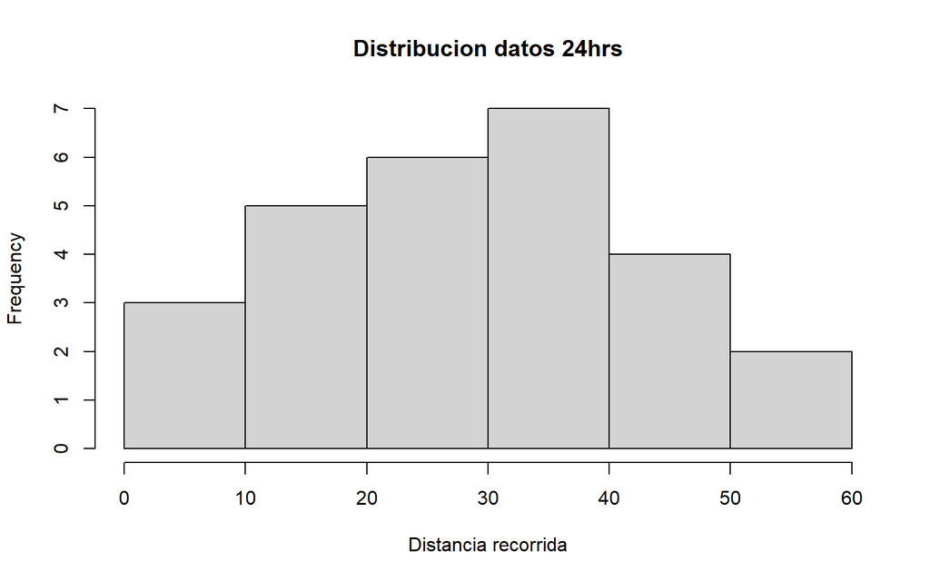

```r
> hist(x = dfdatos1$Distancia24hrs, breaks = 7, xlab = "Distancia recorrida", main = "Distribucion datos 24hrs")
```

## Estandarización

Para el analisis de correlacion no es necesario estandarizar las variables, sin embargo es comun hacerlo pues se puede comparar mas facilmente las variables al estar poder medirlas en terminos de desviaciones estandar

Crearemos una funcion que a cada valor reste la media de su conjunto y el resultado lo divida entre la desviacion estandar del mismo

```r
> Estandarizar <- function(x){
+   (x-mean(x, na.rm = T))/sd(x, na.rm = T)
+ }
```

Y aplicaremos dicha funcion a todas las variables numericas guardandolo en otro datframe, porque los datos originales los utilizaremos al final

```r
> dfdatos1Est <- dfdatos1
> dfdatos1Est[c(2:8)] <- apply(X = dfdatos1Est[c(2:8)], MARGIN = 2, FUN = Estandarizar)
> dfdatos1Est
```

```
## # A tibble: 30 x 11
##    Distancia24hrs NDVI_SMO EVI_SMO NDWI_SMO NDMI_SMO LST_SMO CME_SMO_15
##             <dbl>    <dbl>   <dbl>    <dbl>    <dbl>   <dbl>      <dbl>
##  1           NA     0.863    1.01   -0.924     0.740  -0.772      0.838
##  2           NA     0.579    0.312  -0.895    -0.408  -0.976      0.612
##  3           NA     0.615    0.283  -0.646     0.742  -1.12      -0.821
##  4           18.5   0.545    0.351  -0.472     0.312  -0.961     -0.867
##  5           39.3  -3.11    -0.821   2.91     -2.55   -1.35       0.846
##  6           26.4  -2.44    -0.261   2.21     -2.06   -1.28       0.853
##  7           32.4  -2.44    -0.261   2.21     -2.06   -1.28       0.853
##  8           33.0   0.238   -1.59    0.0184    2.00   -0.794      0.793
##  9           25.7   0.155   -0.224  -0.126     0.329   0.419     -0.950
## 10           51.0  -0.0185  -0.544   0.119    -0.129   0.329     -0.942
## # ... with 20 more rows, and 4 more variables: Altura_de_arbol <dbl>,
## #   Sitio_cons <dbl>, Sex_hembra <dbl>, Temporada_seca <dbl>
```

Comprobaremos que su media es igual a cero y su desviación estandar a uno

```r
> apply(X = dfdatos1Est[c(2:8)], MARGIN = 2, FUN = mean)
```

```
##        NDVI_SMO         EVI_SMO        NDWI_SMO        NDMI_SMO         LST_SMO
##   -6.741650e-16   -6.300382e-16    6.950084e-16   -2.179895e-16   -2.804470e-16
##      CME_SMO_15 Altura_de_arbol
##   -6.864843e-16    5.344484e-17
```

```r
> apply(X = dfdatos1Est[c(2:8)], MARGIN = 2, FUN = sd)
```

```
##        NDVI_SMO         EVI_SMO        NDWI_SMO        NDMI_SMO         LST_SMO
##               1               1               1               1               1
##      CME_SMO_15 Altura_de_arbol
##               1               1
```

> Con los datos ya estandarizados y las variables dummy creadas podemos porceder a realizar los analisis de correlacion

## Correlacion

### Cuantitativas

Nos interesa saber que variables afectan mas a la distancia recorrida asi que podriamos realizar un test de correlacion de cada variable en nuestro conjunto de datos respecto a la distancia. Algo asi:

```r
> cor(dfdatos1Est$Distancia24hrs, dfdatos1Est$EVI_SMO, use ="complete.obs", method = "spearman")
```

```
## [1] -0.5132908
```

Pero seria mas tardado, asi que haremos una matriz de correlaciones para obtener todas de una vez ademas de identificar si algunas de las variables estan relacionadas entre si

Usaremos el coeficiente de correlacion de spearman ya que nos permite evaluar una relacion monotona entre dos variables continuas, es decir cuando las variables cambian al mismo tiempo pero no necesariamentea un ritmo constante a diferencia del coeficiente de pearson que solo evalua una relacion lineal entre las variables.

```r
> correlaciones <- cor(dfdatos1Est[c(1:8)], use ="complete.obs", method = "spearman")
> correlaciones
```

```
##                 Distancia24hrs    NDVI_SMO     EVI_SMO    NDWI_SMO    NDMI_SMO
## Distancia24hrs      1.00000000 -0.38435702 -0.51329077  0.39474505  0.07454937
## NDVI_SMO           -0.38435702  1.00000000  0.35412844 -0.96207951  0.52415902
## EVI_SMO            -0.51329077  0.35412844  1.00000000 -0.27155963 -0.03058104
## NDWI_SMO            0.39474505 -0.96207951 -0.27155963  1.00000000 -0.48073394
## NDMI_SMO            0.07454937  0.52415902 -0.03058104 -0.48073394  1.00000000
## LST_SMO            -0.44057458  0.26544343  0.70764526 -0.23547401 -0.06177370
## CME_SMO_15         -0.23808086 -0.22728664 -0.07555828  0.16794127 -0.09207709
## Altura_de_arbol    -0.16666667 -0.09379778  0.05774521  0.02902537 -0.14207155
##                    LST_SMO  CME_SMO_15 Altura_de_arbol
## Distancia24hrs  -0.4405746 -0.23808086     -0.16666667
## NDVI_SMO         0.2654434 -0.22728664     -0.09379778
## EVI_SMO          0.7076453 -0.07555828      0.05774521
## NDWI_SMO        -0.2354740  0.16794127      0.02902537
## NDMI_SMO        -0.0617737 -0.09207709     -0.14207155
## LST_SMO          1.0000000 -0.30039769      0.30950212
## CME_SMO_15      -0.3003977  1.00000000      0.02750613
## Altura_de_arbol  0.3095021  0.02750613      1.00000000
```

Calcularemos la correlacion en los datos sin estandarizar, solo para comprobar que los resultados no se ven afectados

```r
> correlaciones1 <- cor(dfdatos1[c(1:8)], use ="complete.obs", method = "spearman")
> correlaciones1
```

```
##                 Distancia24hrs    NDVI_SMO     EVI_SMO    NDWI_SMO    NDMI_SMO
## Distancia24hrs      1.00000000 -0.38435702 -0.51329077  0.39474505  0.07454937
## NDVI_SMO           -0.38435702  1.00000000  0.35412844 -0.96207951  0.52415902
## EVI_SMO            -0.51329077  0.35412844  1.00000000 -0.27155963 -0.03058104
## NDWI_SMO            0.39474505 -0.96207951 -0.27155963  1.00000000 -0.48073394
## NDMI_SMO            0.07454937  0.52415902 -0.03058104 -0.48073394  1.00000000
## LST_SMO            -0.44057458  0.26544343  0.70764526 -0.23547401 -0.06177370
## CME_SMO_15         -0.23808086 -0.22728664 -0.07555828  0.16794127 -0.09207709
## Altura_de_arbol    -0.16666667 -0.09379778  0.05774521  0.02902537 -0.14207155
##                    LST_SMO  CME_SMO_15 Altura_de_arbol
## Distancia24hrs  -0.4405746 -0.23808086     -0.16666667
## NDVI_SMO         0.2654434 -0.22728664     -0.09379778
## EVI_SMO          0.7076453 -0.07555828      0.05774521
## NDWI_SMO        -0.2354740  0.16794127      0.02902537
## NDMI_SMO        -0.0617737 -0.09207709     -0.14207155
## LST_SMO          1.0000000 -0.30039769      0.30950212
## CME_SMO_15      -0.3003977  1.00000000      0.02750613
## Altura_de_arbol  0.3095021  0.02750613      1.00000000
```

Y solo por curiosidad lo haremos mediante el metodo de pearson

```r
> corrpearson <- cor(dfdatos1Est[c(1:8)], use ="complete.obs", method = "pearson")
> corrpearson
```

```
##                 Distancia24hrs    NDVI_SMO     EVI_SMO    NDWI_SMO    NDMI_SMO
## Distancia24hrs      1.00000000 -0.27250796 -0.41372637  0.32560777  0.03030038
## NDVI_SMO           -0.27250796  1.00000000  0.25404512 -0.98425281  0.78179112
## EVI_SMO            -0.41372637  0.25404512  1.00000000 -0.25484375 -0.04201221
## NDWI_SMO            0.32560777 -0.98425281 -0.25484375  1.00000000 -0.70750435
## NDMI_SMO            0.03030038  0.78179112 -0.04201221 -0.70750435  1.00000000
## LST_SMO            -0.38458041  0.41793700  0.66718908 -0.37251095  0.06940641
## CME_SMO_15         -0.28931035 -0.14620751 -0.04775861  0.06932989 -0.11482477
## Altura_de_arbol    -0.20126624  0.04567517  0.11807879 -0.05617661 -0.13337825
##                     LST_SMO  CME_SMO_15 Altura_de_arbol
## Distancia24hrs  -0.38458041 -0.28931035     -0.20126624
## NDVI_SMO         0.41793700 -0.14620751      0.04567517
## EVI_SMO          0.66718908 -0.04775861      0.11807879
## NDWI_SMO        -0.37251095  0.06932989     -0.05617661
## NDMI_SMO         0.06940641 -0.11482477     -0.13337825
## LST_SMO          1.00000000 -0.30169079      0.32824584
## CME_SMO_15      -0.30169079  1.00000000      0.04484414
## Altura_de_arbol  0.32824584  0.04484414      1.00000000
```

Con esto vemos que aunque los resultados no son iguales, si son muy similares en cuanto al gardo de correlacion

Pongamos bonitos los resultados (Spearman)

```r
> tab_corr(dfdatos1Est[c(1:8)], corr.method = "spearman")
```

|  | Distancia24hrs | NDVI_SMO | EVI_SMO | NDWI_SMO | NDMI_SMO | LST_SMO | CME_SMO_15 | Altura_de_arbol |
| --- | --- | --- | --- | --- | --- | --- | --- | --- |
| Distancia24hrs |  | -0.384* | -0.513** | 0.395* | 0.075 | -0.441* | -0.238 | -0.167 |
| NDVI_SMO | -0.384* |  | 0.354 | -0.962*** | 0.524** | 0.265 | -0.227 | -0.094 |
| EVI_SMO | -0.513** | 0.354 |  | -0.272 | -0.031 | 0.708*** | -0.076 | 0.058 |
| NDWI_SMO | 0.395* | -0.962*** | -0.272 |  | -0.481* | -0.235 | 0.168 | 0.029 |
| NDMI_SMO | 0.075 | 0.524** | -0.031 | -0.481* |  | -0.062 | -0.092 | -0.142 |
| LST_SMO | -0.441* | 0.265 | 0.708*** | -0.235 | -0.062 |  | -0.300 | 0.310 |
| CME_SMO_15 | -0.238 | -0.227 | -0.076 | 0.168 | -0.092 | -0.300 |  | 0.028 |
| Altura_de_arbol | -0.167 | -0.094 | 0.058 | 0.029 | -0.142 | 0.310 | 0.028 |  |
| Computed correlation used spearman-method with listwise-deletion. |  |  |  |  |  |  |  |  |

```r
> tab_df(as.data.frame(correlaciones), title = "Correlaciones",
+        footnote = "Calculadas por el metodo de Spearman", show.footnote = T,
+        digits = 3, show.rownames = T)
```

Correlaciones

| Row | Distancia24hrs | NDVI_SMO | EVI_SMO | NDWI_SMO | NDMI_SMO | LST_SMO | CME_SMO_15 | Altura_de_arbol |  |
| --- | --- | --- | --- | --- | --- | --- | --- | --- | --- |
| Distancia24hrs | 1.000 | -0.384 | -0.513 | 0.395 | 0.075 | -0.441 | -0.238 | -0.167 |  |
| NDVI_SMO | -0.384 | 1.000 | 0.354 | -0.962 | 0.524 | 0.265 | -0.227 | -0.094 |  |
| EVI_SMO | -0.513 | 0.354 | 1.000 | -0.272 | -0.031 | 0.708 | -0.076 | 0.058 |  |
| NDWI_SMO | 0.395 | -0.962 | -0.272 | 1.000 | -0.481 | -0.235 | 0.168 | 0.029 |  |
| NDMI_SMO | 0.075 | 0.524 | -0.031 | -0.481 | 1.000 | -0.062 | -0.092 | -0.142 |  |
| LST_SMO | -0.441 | 0.265 | 0.708 | -0.235 | -0.062 | 1.000 | -0.300 | 0.310 |  |
| CME_SMO_15 | -0.238 | -0.227 | -0.076 | 0.168 | -0.092 | -0.300 | 1.000 | 0.028 |  |
| Altura_de_arbol | -0.167 | -0.094 | 0.058 | 0.029 | -0.142 | 0.310 | 0.028 | 1.000 |  |
| Calculadas por el metodo de Spearman |  |  |  |  |  |  |  |  |  |

```r
> correlaciones %>%
+     kbl(caption = "CORRELACIONES", digits = 3, align = "c") %>%
+   kable_classic_2(full_width = F) %>%
+   footnote(general = "Calculado por el método de Spearman")
```

CORRELACIONES

|  | Distancia24hrs | NDVI_SMO | EVI_SMO | NDWI_SMO | NDMI_SMO | LST_SMO | CME_SMO_15 | Altura_de_arbol |
| --- | --- | --- | --- | --- | --- | --- | --- | --- |
| Distancia24hrs | 1.000 | -0.384 | -0.513 | 0.395 | 0.075 | -0.441 | -0.238 | -0.167 |
| NDVI_SMO | -0.384 | 1.000 | 0.354 | -0.962 | 0.524 | 0.265 | -0.227 | -0.094 |
| EVI_SMO | -0.513 | 0.354 | 1.000 | -0.272 | -0.031 | 0.708 | -0.076 | 0.058 |
| NDWI_SMO | 0.395 | -0.962 | -0.272 | 1.000 | -0.481 | -0.235 | 0.168 | 0.029 |
| NDMI_SMO | 0.075 | 0.524 | -0.031 | -0.481 | 1.000 | -0.062 | -0.092 | -0.142 |
| LST_SMO | -0.441 | 0.265 | 0.708 | -0.235 | -0.062 | 1.000 | -0.300 | 0.310 |
| CME_SMO_15 | -0.238 | -0.227 | -0.076 | 0.168 | -0.092 | -0.300 | 1.000 | 0.028 |
| Altura_de_arbol | -0.167 | -0.094 | 0.058 | 0.029 | -0.142 | 0.310 | 0.028 | 1.000 |

Note:  
Calculado por el método de Spearman

En la tabla podemos observar lo siguiente:  
**NDVI_SMO** y **NDWI_SMO** presentan una relacion inversa muy fuerte.  
**NDVI_SMO** y **NDMI_SMO** presentan una relacion moderada.  
**EVI_SMO** y **LST_SMO** presentan una relacion fuerte.  
**NDWI_SMO** y **NDMI_SMO** presentan una relacion inversa moderada.

En cuanto a la **Distancia24hrs** (la variable que nos es de interes), vemos que **EVI_SMO** y **LST_SMO** serian las que presentan una ligera relacion inversa

Ordenemos los resultados de forma descendente en base a su valor absoluto tomando unicamente la distancia y pongamos los resultados con una bonita presentacion

```r
> relaciones <- as.data.frame(correlaciones)
> relaciones[order(relaciones$Distancia24hrs),]
```

```
##                 Distancia24hrs    NDVI_SMO     EVI_SMO    NDWI_SMO    NDMI_SMO
## EVI_SMO            -0.51329077  0.35412844  1.00000000 -0.27155963 -0.03058104
## LST_SMO            -0.44057458  0.26544343  0.70764526 -0.23547401 -0.06177370
## NDVI_SMO           -0.38435702  1.00000000  0.35412844 -0.96207951  0.52415902
## CME_SMO_15         -0.23808086 -0.22728664 -0.07555828  0.16794127 -0.09207709
## Altura_de_arbol    -0.16666667 -0.09379778  0.05774521  0.02902537 -0.14207155
## NDMI_SMO            0.07454937  0.52415902 -0.03058104 -0.48073394  1.00000000
## NDWI_SMO            0.39474505 -0.96207951 -0.27155963  1.00000000 -0.48073394
## Distancia24hrs      1.00000000 -0.38435702 -0.51329077  0.39474505  0.07454937
##                    LST_SMO  CME_SMO_15 Altura_de_arbol
## EVI_SMO          0.7076453 -0.07555828      0.05774521
## LST_SMO          1.0000000 -0.30039769      0.30950212
## NDVI_SMO         0.2654434 -0.22728664     -0.09379778
## CME_SMO_15      -0.3003977  1.00000000      0.02750613
## Altura_de_arbol  0.3095021  0.02750613      1.00000000
## NDMI_SMO        -0.0617737 -0.09207709     -0.14207155
## NDWI_SMO        -0.2354740  0.16794127      0.02902537
## Distancia24hrs  -0.4405746 -0.23808086     -0.16666667
```

```r
> rel <- relaciones[order(abs(relaciones$Distancia24hrs), decreasing = T), 1, drop = F]
> rel
```

```
##                 Distancia24hrs
## Distancia24hrs      1.00000000
## EVI_SMO            -0.51329077
## LST_SMO            -0.44057458
## NDWI_SMO            0.39474505
## NDVI_SMO           -0.38435702
## CME_SMO_15         -0.23808086
## Altura_de_arbol    -0.16666667
## NDMI_SMO            0.07454937
```

ORDEN DE CORRELACION RESPECTO A LA DISTANCIA

|  | Distancia24hrs |
| --- | --- |
| Distancia24hrs | 1.000 |
| EVI_SMO | -0.513 |
| LST_SMO | -0.441 |
| NDWI_SMO | 0.395 |
| NDVI_SMO | -0.384 |
| CME_SMO_15 | -0.238 |
| Altura_de_arbol | -0.167 |
| NDMI_SMO | 0.075 |

Note:  
Calculado por el método de Spearman

Para estar seguros de los resultados anteriores calcularemos su grado de significancia

```r
> probcor <- Hmisc::rcorr(as.matrix(dfdatos1Est[c(1:8)]), type = "spearman")
> probcor$P
```

```
##                 Distancia24hrs    NDVI_SMO      EVI_SMO   NDWI_SMO    NDMI_SMO
## Distancia24hrs              NA 0.047764325 0.0061781586 0.04158029 0.711714083
## NDVI_SMO           0.047764325          NA 0.0197073847 0.00000000 0.006000369
## EVI_SMO            0.006178159 0.019707385           NA 0.07416740 0.828811001
## NDWI_SMO           0.041580293 0.000000000 0.0741674028         NA 0.023062029
## NDMI_SMO           0.711714083 0.006000369 0.8288110015 0.02306203          NA
## LST_SMO            0.021445620 0.434659399 0.0005635191 0.52122630 0.647185188
## CME_SMO_15         0.231752693 0.363965202 0.9822843252 0.58338603 0.756581433
## Altura_de_arbol    0.406040897 0.710960983 0.7162054136 0.92650668 0.274962081
##                      LST_SMO CME_SMO_15 Altura_de_arbol
## Distancia24hrs  0.0214456203 0.23175269       0.4060409
## NDVI_SMO        0.4346593990 0.36396520       0.7109610
## EVI_SMO         0.0005635191 0.98228433       0.7162054
## NDWI_SMO        0.5212262970 0.58338603       0.9265067
## NDMI_SMO        0.6471851876 0.75658143       0.2749621
## LST_SMO                   NA 0.08268502       0.1489731
## CME_SMO_15      0.0826850169         NA       0.8043398
## Altura_de_arbol 0.1489730577 0.80433981              NA
```

Y tambien los ordenaremos respecto a la distancia

```r
> probcor1 <- as.data.frame(probcor$P)
> probcor1[order(probcor1$Distancia24hrs), 1 , drop = F]
```

```
##                 Distancia24hrs
## EVI_SMO            0.006178159
## LST_SMO            0.021445620
## NDWI_SMO           0.041580293
## NDVI_SMO           0.047764325
## CME_SMO_15         0.231752693
## Altura_de_arbol    0.406040897
## NDMI_SMO           0.711714083
## Distancia24hrs              NA
```

```r
> probcor1 <- probcor1[order(probcor1$Distancia24hrs), 1 , drop = F]
> probcor1
```

```
##                 Distancia24hrs
## EVI_SMO            0.006178159
## LST_SMO            0.021445620
## NDWI_SMO           0.041580293
## NDVI_SMO           0.047764325
## CME_SMO_15         0.231752693
## Altura_de_arbol    0.406040897
## NDMI_SMO           0.711714083
## Distancia24hrs              NA
```

Aquellas que tengan un p_value menor a 0.05 son aquellas que se puede afirmar que presentan una relacion

Pongamos presentables los resultados

SIGNIFICANCIA DE LAS CORRELACIONES

|  | Distancia24hrs | NDVI_SMO | EVI_SMO | NDWI_SMO | NDMI_SMO | LST_SMO | CME_SMO_15 | Altura_de_arbol |
| --- | --- | --- | --- | --- | --- | --- | --- | --- |
| Distancia24hrs | NA | 0.048 | 0.006 | 0.042 | 0.712 | 0.021 | 0.232 | 0.406 |
| NDVI_SMO | 0.048 | NA | 0.020 | 0.000 | 0.006 | 0.435 | 0.364 | 0.711 |
| EVI_SMO | 0.006 | 0.020 | NA | 0.074 | 0.829 | 0.001 | 0.982 | 0.716 |
| NDWI_SMO | 0.042 | 0.000 | 0.074 | NA | 0.023 | 0.521 | 0.583 | 0.927 |
| NDMI_SMO | 0.712 | 0.006 | 0.829 | 0.023 | NA | 0.647 | 0.757 | 0.275 |
| LST_SMO | 0.021 | 0.435 | 0.001 | 0.521 | 0.647 | NA | 0.083 | 0.149 |
| CME_SMO_15 | 0.232 | 0.364 | 0.982 | 0.583 | 0.757 | 0.083 | NA | 0.804 |
| Altura_de_arbol | 0.406 | 0.711 | 0.716 | 0.927 | 0.275 | 0.149 | 0.804 | NA |

Note:  
Calculado por el método de Spearman

ORDEN DE SIGNIFICANCIA RESPECTO A LA DISTANCIA

|  | Distancia24hrs |
| --- | --- |
| EVI_SMO | 0.006 |
| LST_SMO | 0.021 |
| NDWI_SMO | 0.042 |
| NDVI_SMO | 0.048 |
| CME_SMO_15 | 0.232 |
| Altura_de_arbol | 0.406 |
| NDMI_SMO | 0.712 |
| Distancia24hrs | NA |

Note:  
Calculado por el método de Spearman

Aquellas que tengan un p_value menor a 0.05 son aquellas que se puede afirmar que presentan una relacion

Con la informacion de las tablas anterior podemos ver cuales son las variables que tienen mayor relacion con la distancia recorrida asi como entre ellas

Grafiquemos los resultados obtenidos

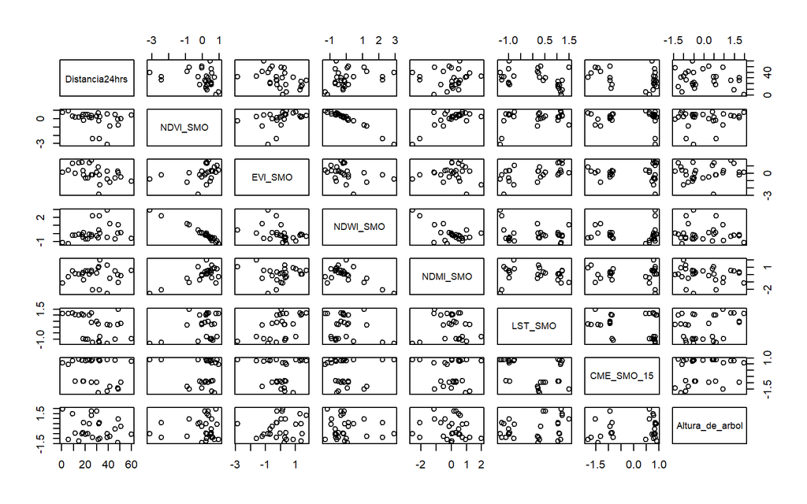

```r
> pairs(dfdatos1Est[c(1:8)])
```

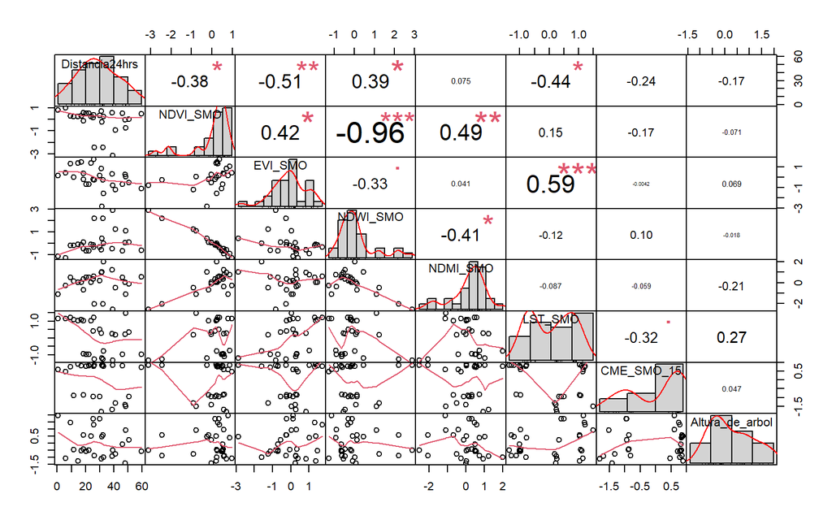

```r
> PerformanceAnalytics::chart.Correlation(dfdatos1Est[c(1:8)], histogram = T,
+                                         method = "spearman")
```

Pongamos todo en una sola grafica

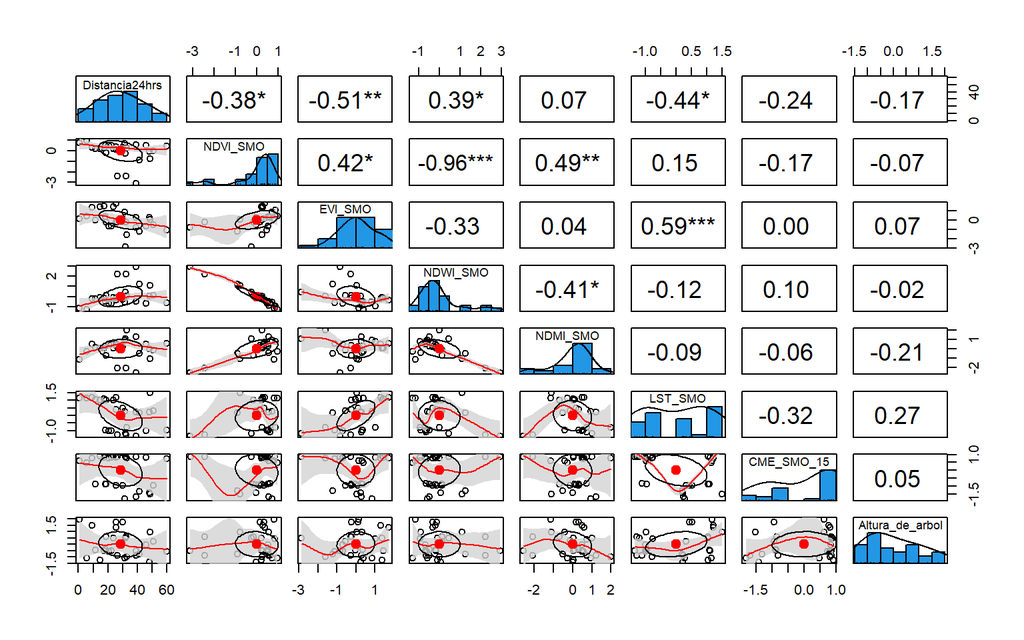

```r
> psych::pairs.panels(dfdatos1Est[c(1:8)], method = "spearman", stars = TRUE,
+              hist.col = 4, smooth = TRUE, scale = F, density = TRUE,
+              pch = 21, lm = F, jiggle = T, ci = TRUE)
```

> Con esto ya tenemos claro cuales variables cuantitativas influyen mas en la distancia

### Categoricas

Veamos visualmente como estan distribuidas las variables categoricas

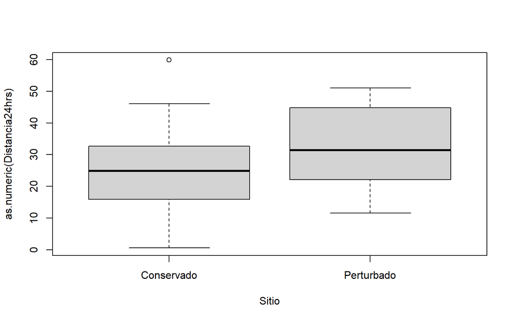

```r
> boxplot(formula = as.numeric(Distancia24hrs) ~ Sitio, data = na.omit(dfdatosori),
+         na.action=na.pass)
```

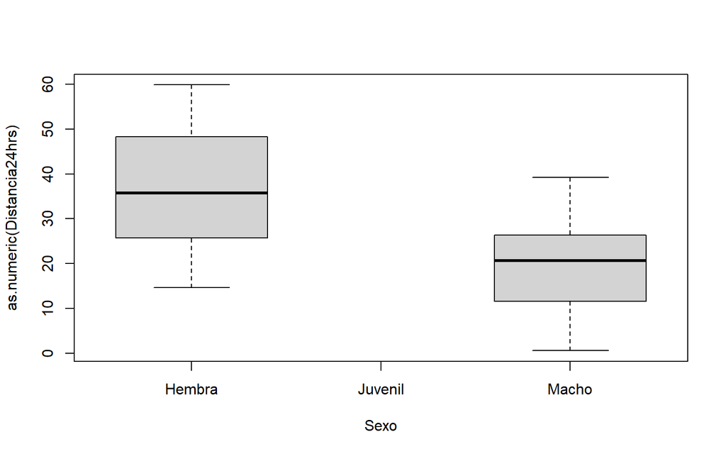

```r
> boxplot(formula = as.numeric(Distancia24hrs) ~ Sexo, data = na.omit(dfdatosori),
+         na.action=na.pass)
```

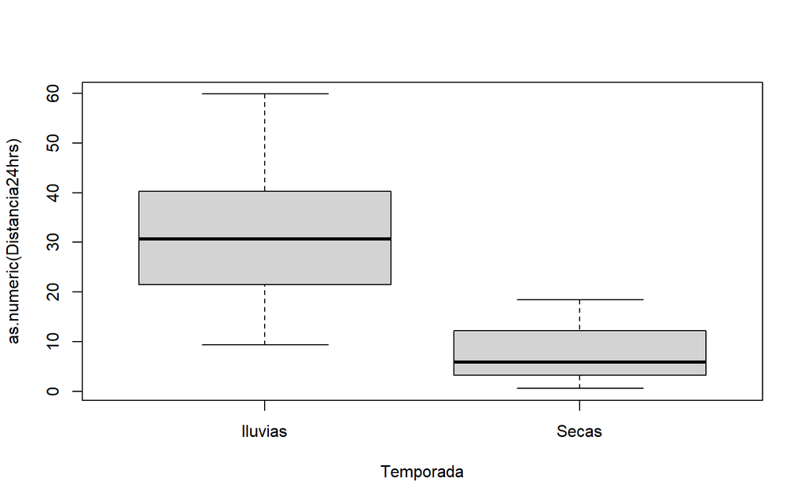

```r
> boxplot(formula = as.numeric(Distancia24hrs) ~ Temporada, data = na.omit(dfdatosori),
+         na.action=na.pass)
```

Podemos observar que el `Sitio perturbado`, `Sexo_hembra` y `Temporada_lluvias` presentan mayores distancias que su contraparte

Sin embargo eso no nos dice cual de las tres influya mas en la distanca, para determinarlo usaremos un metodo llamado point biserial correlation, que nos permite calcular la correlacion entre una variable categorica y una cuantitativa.

```r
> relacionSexo <- cor.test(dfdatos1Est$Sex_hembra, dfdatos1Est$Distancia24hrs)
> relacionSitio <- cor.test(dfdatos1Est$Sitio_cons, dfdatos1Est$Distancia24hrs)
> relacionTemporada <- cor.test(dfdatos1Est$Temporada_seca, dfdatos1Est$Distancia24hrs)
>
> print(relacionSexo)
```

```
##
##  Pearson's product-moment correlation
##
## data:  dfdatos1Est$Sex_hembra and dfdatos1Est$Distancia24hrs
## t = 3.3459, df = 25, p-value = 0.002593
## alternative hypothesis: true correlation is not equal to 0
## 95 percent confidence interval:
##  0.2233307 0.7728276
## sample estimates:
##       cor
## 0.5561453
```

```r
> print(relacionSitio)
```

```
##
##  Pearson's product-moment correlation
##
## data:  dfdatos1Est$Sitio_cons and dfdatos1Est$Distancia24hrs
## t = -1.322, df = 25, p-value = 0.1981
## alternative hypothesis: true correlation is not equal to 0
## 95 percent confidence interval:
##  -0.5793577  0.1377749
## sample estimates:
##        cor
## -0.2556226
```

```r
> print(relacionTemporada)
```

```
##
##  Pearson's product-moment correlation
##
## data:  dfdatos1Est$Temporada_seca and dfdatos1Est$Distancia24hrs
## t = -2.8654, df = 25, p-value = 0.008324
## alternative hypothesis: true correlation is not equal to 0
## 95 percent confidence interval:
##  -0.7378180 -0.1445028
## sample estimates:
##        cor
## -0.4972133
```

Las ordenaremos de acuerdo a su grado de significancia

```r
> v <- c(relacionSexo$p.value, relacionSitio$p.value, relacionTemporada$p.value)
> names(v) <- c("Sexo", "Sitio", "Temporada")
> v <- as.data.frame(v[order(v)])
> names(v) <- "p_value"
> v
```

```
##               p_value
## Sexo      0.002593108
## Temporada 0.008324031
## Sitio     0.198125877
```

ORDEN DE SIGNIFICANCIA

|  | p_value |
| --- | --- |
| Sexo | 0.003 |
| Temporada | 0.008 |
| Sitio | 0.198 |

Note:  
Point biserial correlation

Graficando los resultados

```r
> dfdatos1Est1 <- na.omit(dfdatos1Est)
> dfdatos1Est1
```

```
## # A tibble: 27 x 11
##    Distancia24hrs NDVI_SMO EVI_SMO NDWI_SMO NDMI_SMO LST_SMO CME_SMO_15
##             <dbl>    <dbl>   <dbl>    <dbl>    <dbl>   <dbl>      <dbl>
##  1           18.5   0.545    0.351  -0.472   0.312    -0.961     -0.867
##  2           39.3  -3.11    -0.821   2.91   -2.55     -1.35       0.846
##  3           26.4  -2.44    -0.261   2.21   -2.06     -1.28       0.853
##  4           32.4  -2.44    -0.261   2.21   -2.06     -1.28       0.853
##  5           33.0   0.238   -1.59    0.0184  2.00     -0.794      0.793
##  6           25.7   0.155   -0.224  -0.126   0.329     0.419     -0.950
##  7           51.0  -0.0185  -0.544   0.119  -0.129     0.329     -0.942
##  8           48.3  -0.0264   0.256   0.0699  0.00280   0.219     -1.42
##  9           39.0   0.571    0.277  -0.468   1.24      0.239     -1.69
## 10           41.3  -0.910   -1.23    1.24   -0.497     0.181     -1.32
## # ... with 17 more rows, and 4 more variables: Altura_de_arbol <dbl>,
## #   Sitio_cons <dbl>, Sex_hembra <dbl>, Temporada_seca <dbl>
```

```r
> cor(dfdatos1Est1[9:11])
```

```
##                 Sitio_cons Sex_hembra Temporada_seca
## Sitio_cons      1.00000000 -0.3464174     0.05330018
## Sex_hembra     -0.34641737  1.0000000    -0.36689969
## Temporada_seca  0.05330018 -0.3668997     1.00000000
```

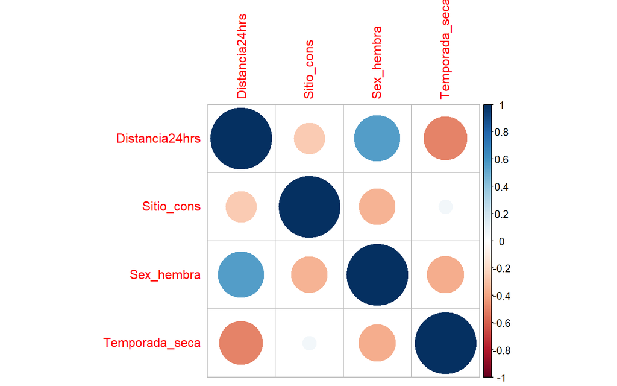

```r
> corrplot::corrplot(cor(dfdatos1Est1[c(1, 9:11)]))
```

Basandonos en el *p_value* haremos una lista con el orden de importancia de nuestro dataset para la variable `Distancia24hrs` con su respectiva tabla

```r
> names(v) <- names(probcor1)
> str(rbind(v,probcor1))
```

```
## 'data.frame':    11 obs. of  1 variable:
##  $ Distancia24hrs: num  0.00259 0.00832 0.19813 0.00618 0.02145 ...
```

```r
> importancia_variables <- rbind(probcor1, v)
> importancia_variables <-  importancia_variables[order(importancia_variables), ,
+                                                 drop = F]
>
> importancia_variables
```

```
##                 Distancia24hrs
## Sexo               0.002593108
## EVI_SMO            0.006178159
## Temporada          0.008324031
## LST_SMO            0.021445620
## NDWI_SMO           0.041580293
## NDVI_SMO           0.047764325
## Sitio              0.198125877
## CME_SMO_15         0.231752693
## Altura_de_arbol    0.406040897
## NDMI_SMO           0.711714083
## Distancia24hrs              NA
```

ORDEN DE SIGNIFICANCIA RESPECTO A LA DISTANCIA POR DIA

|  | Distancia24hrs |
| --- | --- |
| Sexo | 0.003 |
| EVI_SMO | 0.006 |
| Temporada | 0.008 |
| LST_SMO | 0.021 |
| NDWI_SMO | 0.042 |
| NDVI_SMO | 0.048 |
| Sitio | 0.198 |
| CME_SMO_15 | 0.232 |
| Altura_de_arbol | 0.406 |
| NDMI_SMO | 0.712 |

Note:  
Valores redondeados